# Excersice Sheet 6

A broker wants to use linear regression to find out which factors have a large influence on the price of a property. For this purpose, the variables described in Table 1 are given for the last 88 sales in the broker’s region.

Table 1 House price record

| Variabel | Description |
| --- | --- |
| `price` | house price ($\times$ 1,000 EUR) |
| `bdrms` | number bedrooms |
| `lotsize` | parking area (m$^2$) |
| `sqrm` | house area (m$^2$) |
| `country` | $==1$ when in country house style |
| `lprice` | `log(price)` |
| `llotsize` | `log(lotsize)` |
| `lsqrm` | `log(sqrm)` |

1. Create a linear regression model with `price` as dependent variable and `bdrms`, `lotsize`, `sqrm` und `country` as independent variables.
   1. Determine the regression coefficients and $p$-values of the dependent variable and compare their influence within the model on the predicted value for `price`.
   2. Determine how much variance of the dependent variable is explained.
   3. Check the residuals (graphically) for normal distribution and homoskedasticity.

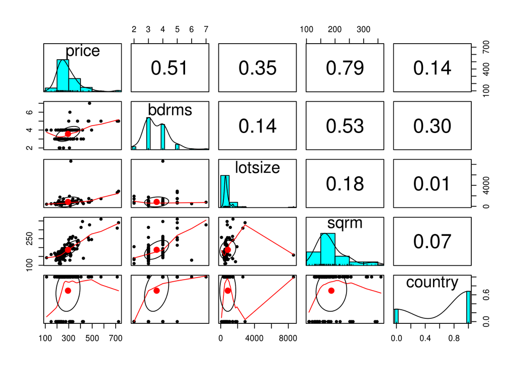

```r
# Solution for Task 1...
library(stringr)
library(readr)
library(dplyr)
library(psych)
library(caTools)
library(PerformanceAnalytics)

dataset <- read_csv("hprice.csv")

dataset.reg <- subset(dataset, select=c(price,bdrms, lotsize, sqrm,country))

pairs.panels(dataset.reg,col="red")
```

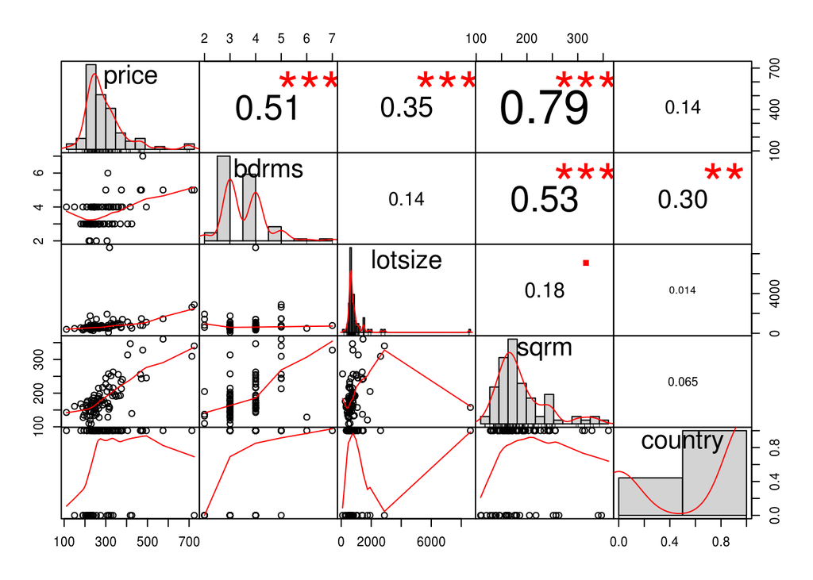

```r
chart.Correlation(dataset.reg,hist=T)
```

```r
regressor = lm(formula = price ~ .,
               data = dataset.reg)

print(summary(regressor)$coefficient)
```

```
##                 Estimate   Std. Error    t value     Pr(>|t|)
## (Intercept) -24.12652827 29.603454535 -0.8149903 4.174103e-01
## bdrms        11.00429220  9.515260399  1.1564888 2.507991e-01
## lotsize       0.02234481  0.006917665  3.2301082 1.774189e-03
## sqrm          1.33732481  0.143576518  9.3143700 1.534380e-14
## country      13.71554214 14.637265211  0.9370290 3.514622e-01
```

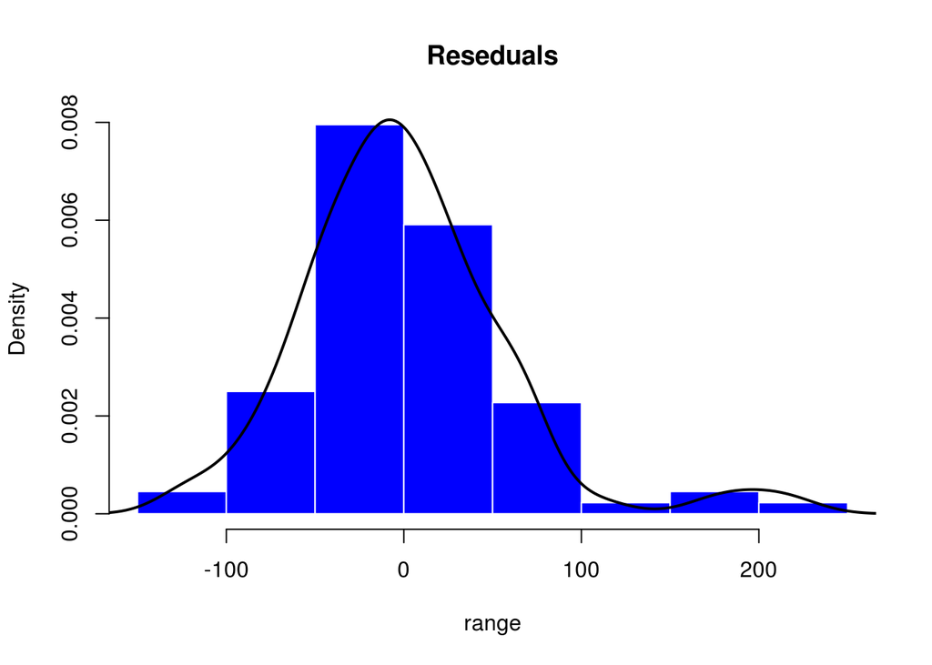

```r
hist(residuals(regressor), # histogram
     col="blue", # column color
     border="white",
     prob = TRUE, # show densities instead of frequencies
     xlab = "range",
     main = "Reseduals")
lines(density(residuals(regressor)), # density plot
      lwd = 2, # thickness of line
      col = "black")
```

2. Given be the linear regression model from task 1.
   1. Create a scatterplot to display the relationship between the predicted value for `price` and the residual size.
   2. For some houses, the price forecast of the broker model is more than EUR 100,000 off. Highlight houses with a residual size of more than 100 or less than 100. What could be the reasons for high model inaccuracies?
   3. Can the $R^2$-value be increased by using a linear transformation of one of the independent variables?

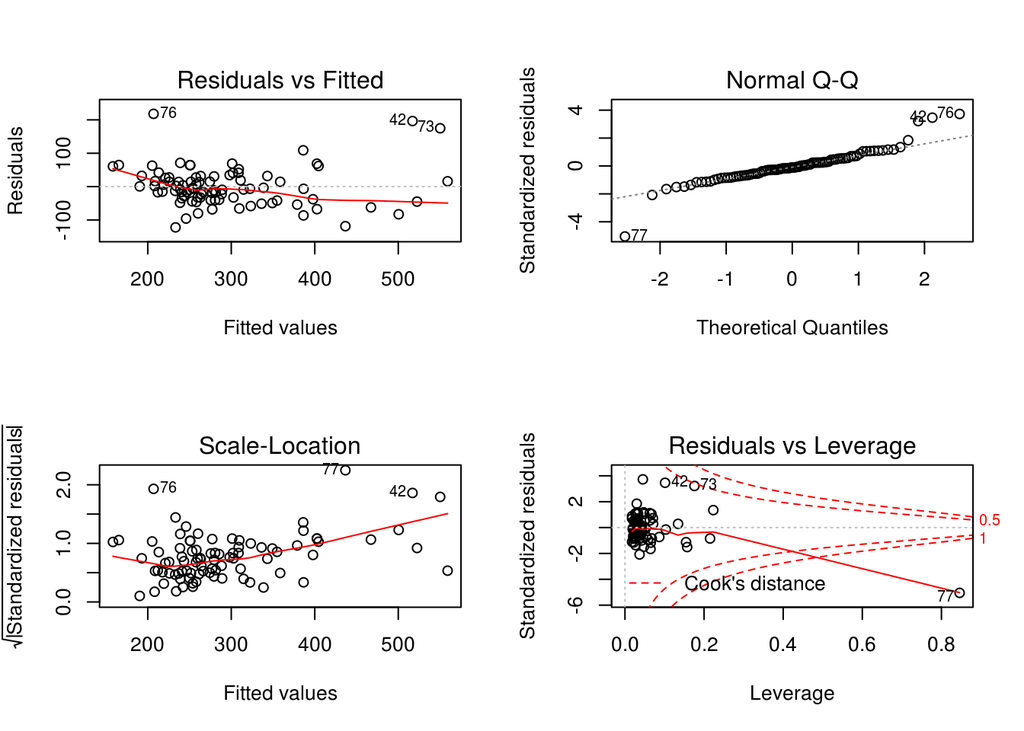

```r
# Solution for Task 2...
par(mfrow=c(2,2))
plot(regressor)
```

3. Graphically display the relationship between `bdrms` and `price`. Check whether this relationship is also reflected in the regression model from Task 1. Create a regression model with `bdrms` as the only independent variable. Compare the regression coefficients with those of the model from Task 1 and interpret the differences.

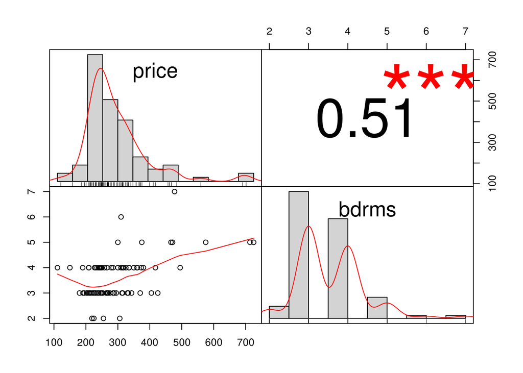

```r
# Solution for Task 3...

dataset.bedrom <- subset(dataset, select=c(price,bdrms))

chart.Correlation(dataset.bedrom,hist=T)
```

```r
model <- lm(fromula= price ~ bedrms,data = dataset.bedrom)
```

Dataset:

- http://isgwww.cs.uni-magdeburg.de/cv/lehre/VisAnalytics/material/exercise/datasets/hprice.csv